# 2024年巴菲特致股东的信

2025年2月22日

沃伦·E·巴菲特(Warren E. Buffett)

董事会主席

| **年份** | **伯克希尔股价变动** | **标普500含股息收益率** |
| --- | --- | --- |
| **1965** | 49.5% | 10.0% |
| **1966** | -3.4% | -11.7% |
| **1967** | 13.3% | 30.9% |
| **1968** | 77.8% | 11.0% |
| **1969** | 19.4% | -8.4% |
| **1970** | -4.6% | 3.9% |
| **1971** | 80.5% | 14.6% |
| **1972** | 8.1% | 18.9% |
| **1973** | -2.5% | -14.8% |
| **1974** | -48.7% | -26.4% |
| **1975** | 2.5% | 37.2% |
| **1976** | 129.3% | 23.6% |
| **1977** | -7.4% | -7.4% |
| **1978** | 14.5% | 6.4% |
| **1979** | 102.5% | 18.2% |
| **1980** | 32.8% | 32.3% |
| **1981** | 31.8% | -5.0% |
| **1982** | 38.4% | 21.4% |
| **1983** | 69.0% | 22.4% |
| **1984** | -2.7% | 6.1% |
| **1985** | 93.7% | 31.6% |
| **1986** | 14.2% | 18.6% |
| **1987** | 4.6% | 5.1% |
| **1988** | 59.3% | 16.6% |
| **1989** | 84.6% | 31.7% |
| **1990** | -23.1% | -3.1% |
| **1991** | 35.6% | 30.5% |
| **1992** | 29.8% | 7.6% |
| **1993** | 38.9% | 10.1% |
| **1994** | 25.0% | 1.3% |
| **1995** | 57.4% | 37.6% |
| **1996** | 6.2% | 23.0% |
| **1997** | 34.9% | 33.4% |
| **1998** | 52.2% | 28.6% |
| **1999** | -19.9% | 21.0% |
| **2000** | 26.6% | -9.1% |
| **2001** | 6.5% | -11.9% |
| **2002** | -3.8% | -22.1% |
| **2003** | 15.8% | 28.7% |
| **2004** | 4.3% | 10.9% |
| **2005** | 0.8% | 4.9% |
| **2006** | 24.1% | 15.8% |
| **2007** | 28.7% | 5.5% |
| **2008** | -31.8% | -37.0% |
| **2009** | 2.7% | 26.5% |
| **2010** | 21.4% | 15.1% |
| **2011** | -4.7% | 2.1% |
| **2012** | 16.8% | 16.0% |
| **2013** | 32.7% | 32.4% |
| **2014** | 27.0% | 13.7% |
| **2015** | -12.5% | 1.4% |
| **2016** | 23.4% | 12.0% |
| **2017** | 21.9% | 21.8% |
| **2018** | 2.8% | -4.4% |
| **2019** | 11.0% | 31.5% |
| **2020** | 2.4% | 18.4% |
| **2021** | 29.6% | 28.7% |
| **2022** | 4.0% | -18.1% |
| **2023** | 15.8% | 26.3% |
| **2024** | 25.5% | 25.0% |
| **复合年化收益率** | **19.9%** | **10.4%** |
| **累计总收益率** | **5,502,284%** | **39,054%** |

**致伯克希尔·哈撒韦公司股东：**

这封信作为伯克希尔年度报告的一部分寄送给你们。作为一家上市公司，我们必须定期向你们披露许多具体的事实和数据。

然而，“报告”这个词意味着更大的责任。除了法定信息外，我们认为自己还应当向你们提供额外的解读，让你们更清楚地了解所持有的公司以及我们的思考方式。

我们的目标是：用我们希望你们对待我们资产的方式，与你们沟通——换句话说，如果你们是伯克希尔的CEO，而我和我的家人是信任你们、将储蓄托付给你们的被动投资者，我们会希望收到怎样的信息？

因此，每年我们都会向你们报告伯克希尔旗下众多业务的发展情况，无论是好消息还是坏消息。

在谈及子公司出现的问题时，我们尽量遵循汤姆·墨菲（Tom Murphy）60年前给我的忠告：“点名表扬，批评归类。”

**错误——是的，伯克希尔也会犯错**

有时候，我在评估伯克希尔收购业务的未来经济前景时，判断失误，导致资本配置出现错误。这种情况既可能发生在流通股的投资（我们将其视为部分企业所有权），也可能发生在全资收购的企业上。

此外，在评估伯克希尔雇佣的管理者时，我有时也会看走眼，无论是对其能力还是忠诚度的判断。忠诚度的失望不仅仅带来财务损失，它带来的痛苦有时堪比一场失败的婚姻。

在人才决策上，能做到的最佳水平不过是有个像样的击球率（batting average，即成功率）。但最严重的错误，是在发现问题后迟迟不做出纠正——正如查理·芒格所说的：“别再吮拇指了。”

查理总是告诉我：问题不会凭空消失，它们需要行动，无论这件事多么令人不适。

在 2019-2023 年间，我在写给你的股东信中共使用了16次“错误”或“失误”这个词。

与此同时，许多庞大的企业在这五年间从未承认过任何错误。不过，我得说，亚马逊在2021年的股东信中做出了一些极其坦诚的反思。

但在大多数情况下，外界看到的只是“正能量”的宣传和精美的图片。

我曾担任过几家大型上市公司的董事，在这些公司里，“错误”或“失误”是董事会会议和分析师电话会议上的禁忌词。

这种暗示管理层“完美无缺”的禁忌文化总让我感到不安。（当然，在某些情况下，由于法律因素，限制讨论可能是明智之举，毕竟我们生活在一个高度诉讼化的社会。）

* * * * * * * * * * * *

我已经 94 岁了，再过不久，格雷格·阿贝尔（Greg Abel）将接替我担任 CEO，并开始撰写年度股东信。

格雷格与我一样，坚守伯克希尔的信条——即 “报告”不仅仅是年度例行公事，而是伯克希尔CEO对股东的责任。

同时，他也深知，一旦你开始欺骗股东，很快你就会连自己也骗过去。

**彼特·利格尔：独一无二的企业家**

让我暂停一下，讲述彼特·利格尔（Pete Liegl） 的非凡故事。

彼特对大多数伯克希尔股东来说或许是个陌生的名字，但他为伯克希尔的整体财富贡献了数十亿美元。

我第一次听说彼特创立并管理的森林河公司（Forest River）——一家位于印第安纳州的房车（RV）制造商，是在2005年6月21日。

那天，我收到一封来自中间人的信，其中详细列出了该公司的相关数据。信中提到，彼特100%控股森林河，并且明确希望将公司卖给伯克希尔。同时，信中直接列出了 彼特期望的出售价格。

我喜欢这种干脆利落的方式。

于是，我联系了一些房车经销商做了调查，结果让我非常满意，于是我安排了6月 28 日在奥马哈的会面。那天，彼特带着他的妻子Sharon和女儿Lisa一起来见我。

在会谈中，彼特直言不讳地表示，他想继续经营公司，但希望能确保家人的财务安全。

接着，他提到，他还持有一些房地产，这些房产租赁给了森林河，但并未在6月21 日的信件中提及。仅用了几分钟，我们便谈妥了这部分资产的价格。

我没有要求伯克希尔进行评估，而是直接接受了他的估值。

随后，我们讨论了他的薪酬问题。我问彼特：“你希望拿多少薪水？”

我补充道：“无论你说多少，我都会接受。”（顺便一提，这种方式不适用于一般商业谈判。）

彼特停顿了一下，此时，他的妻子、女儿和我都紧张地向前倾身，等着他开口。

然后，他的回答让我们所有人都大吃一惊：

“我看了伯克希尔的股东代理声明，不想拿比我的老板更多的薪水，所以给我10万美元年薪就行。”

听完这话，我整个人差点从椅子上摔下来。

然后，彼特补充道：“不过，今年我们预计能赚 X（他提了个具体数字），我希望拿年度利润超额部分的10%作为奖金。”

我回答道：“好的，彼特，但如果森林河未来进行重大收购，我们会根据额外资本的使用情况，调整你的奖金。”

不过，我并没有具体定义“重大收购”或“适当调整”，但这些模糊条款从未成为问题。

那天晚上，我们四人一起去了奥马哈的欢乐谷俱乐部共进晚餐，从此皆大欢喜。

在接下来的19年里，彼特大放异彩，他的竞争对手无人能及。

* * * * * * * * * * * *

并不是每家公司都拥有清晰易懂的商业模式，而且像彼特这样的杰出企业家和管理者更是凤毛麟角。

当然，伯克希尔在收购业务时，我难免会犯错，有时在评估生意本身时判断失误，有时则是在评估与我打交道的人时看走眼。

但与此同时，我也经历过许多意想不到的惊喜——无论是对企业潜力的发现，还是对管理者能力与忠诚度的认可。

我们的经验表明，一个正确的决策，足以带来惊人的长期回报。例如选择GEICO作为投资标的；任命阿吉特·贾恩（Ajit Jain）为管理者；与查理·芒格独一无二的合作伙伴关系，他是我的私人顾问更是坚定不移的朋友。

错误终会被遗忘，而赢家可以持续开花结果。

* * * * * * * * * * * *

在挑选CEO时，我从不关心候选人在哪所学校就读，绝对不会！

当然，顶级学府也培养出了一些优秀的管理者。但与此同时，还有很多像彼特这样的人，他们或许从非名校毕业，甚至干脆没有完成学业，但这并不妨碍他们成为卓越的商业领袖。

看看我的朋友比尔·盖茨（Bill Gates），他选择投身正在改变世界的爆炸性行业，而不是留在校园里拿一张可以挂在墙上的文凭。（推荐阅读他的新书《源代码》（Source Code））

不久前，我通过电话认识了杰西卡·通克尔（Jessica Toonkel），她的继祖父本·罗斯纳（Ben Rosner） 早年曾为查理和我经营过一家零售公司。

本是一位零售天才，在撰写这封股东信时，我特意向杰西卡确认了一下本的受教育情况，因为我记得他受教育程度有限。

杰西卡的回复是：“本连六年级都没读完。”

我很幸运，曾在三所优秀的大学接受教育，并且我坚信终身学习的价值。但在我的观察中，绝大部分商业才能来自天赋，而非教育培养。

彼特·利格尔就是个天生的企业家。

彼特·利格尔就是个天生的企业家。

[figure not shown]

图：皮特·利格（Pete Liegl）

**去年的业绩**

2024年，伯克希尔的表现超出了我的预期，尽管我们189家运营子公司中有53%的企业报告了利润下滑。我们的投资收益大幅增长，这是可以预见的，因为随着国债收益率的上升，我们大幅增加了这些高流动性的短期证券的持有量。

我们的保险业务也实现了显著的盈利增长，其中GEICO的表现尤为突出。在过去五年里，托德·库姆斯对GEICO进行了重大改革，提升了运营效率，并使承保流程与时俱进。

GEICO这颗长期以来的“宝石”确实需要重新打磨，而托德夜以继日地完成了这项工作。尽管尚未彻底完成，但2024年的进步已经十分惊人。

纵观2024 年，财产与意外险的定价有所上调，这反映出强对流风暴带来的损失显著增加。气候变化或许正在宣告它的到来。

不过，2024年并未发生“灾难性”事件。但总有一天，甚至随时，一场真正惊人的保险损失将会发生——而且我们无法保证每年只有一次这样的损失。

财产与意外险业务对伯克希尔而言至关重要，因此在本信稍后部分，我将对此作进一步探讨。

伯克希尔的铁路和公用事业业务（这是除保险业务外最大的两大业务）整体盈利有所改善。但这两个业务仍有很多工作要做。

在2024年末，我们将公用事业业务的持股比例从约92%提高至100%，交易总价约为 39亿美元，其中29亿美元以现金支付，其余部分通过伯克希尔B类股支付。

* * * * * * * * * * * *

2024年，我们营业利润474亿美元。尽管某些读者可能对我们的反复强调感到厌倦，但我们必须重申：相较于（年报）第K-68页按通用会计准则（GAAP）要求列示的利润，这个运营利润指标更能反映企业真实经营状况。

我们采用的指标不包含我们所持股票和债券的资本收益或损失，无论这些收益或损失是已实现的还是未实现的。

从长期来看，我们认为获利的可能性极大——否则，我们又为何要投资这些证券呢？

不过，这些投资的年度波动将是剧烈且不可预测的。

我们的投资视野几乎总是远超一年，在许多情况下，我们的思考跨度是数十年。

正是这些长期持有的资产，时不时会让“收银机”响得像教堂钟声一样。

以下是我们对 2023-2024年盈利的分类计算。所有数据均为扣除折旧、摊销及所得税后的结果。

至于EBITDA ——华尔街的“心头好”，但在我们看来，这是个有缺陷的指标，因此我们从不使用它。

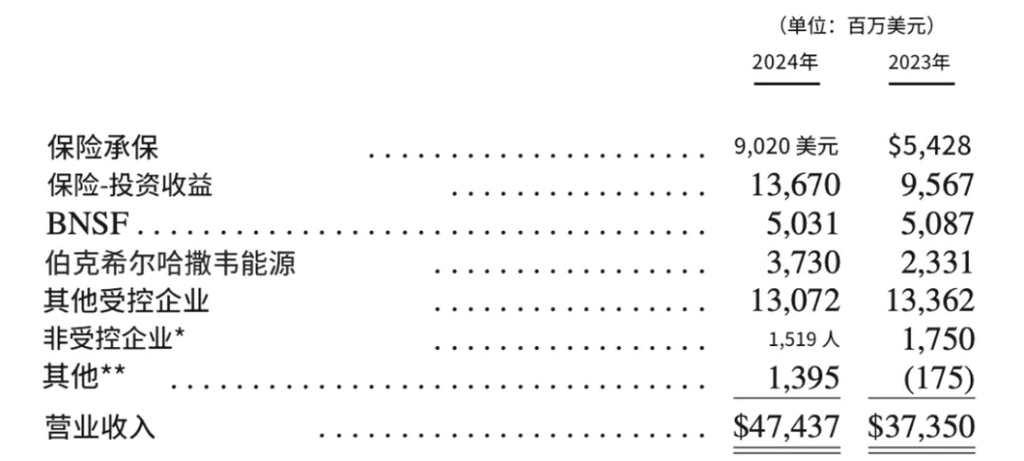

注：*包括伯克希尔持股比例在20%至50%之间的部分企业，如卡夫亨氏、西方石油和 Berkadia。

** 2024 年，我们因使用非美元计价债务，录得约 11 亿美元 的外汇收益，而 2023 年的相关收益约为 2.11 亿美元。

**惊喜，惊喜！一项重要的美国纪录被打破**

60年前，现任管理层接管了伯克希尔。这是一个错误——我的错误——并且在接下来的20年里，这个错误一直困扰着我们。

我要特别强调，查理（芒格）立即就看出了我的明显失误：尽管我买入伯克希尔的价格看似便宜，但这家北方大型纺织企业的业务已注定走向消亡。

美国财政部早已收到了关于伯克希尔命运的无声警示。1965 年，这家公司没有缴纳一分钱的企业所得税，而这种情况在过去十年里几乎成了常态。

这种经济状况也许在那些炙手可热的初创企业中还能理解，但如果发生在一家曾经被视为美国工业支柱的公司身上，那无疑是一个闪烁的黄灯警告。伯克希尔正朝着废纸篓的方向滑落。

时间快进60年，试想一下财政部的惊讶：这家依然沿用“伯克希尔·哈撒韦”名字的公司，去年缴纳的企业所得税远超美国政府历史上从任何一家公司收到的税款，甚至超过了市值达数万亿美元的美国科技巨头。

请注意，这一创纪录税款背后的关键因素：在1965-2024年间，伯克希尔的股东仅收到过一次现金股息！

1967年1月3日，我们发放了唯一一次股息，总额101,755美元，即每股A类股份 10 美分。（我已经不记得当时为何向董事会提出这个建议了。现在回想起来，就像一场噩梦。）

60年来，伯克希尔的股东始终支持持续再投资，这使公司得以不断扩大应税收入。伯克希尔向美国财政部缴纳的现金所得税，从最初十年的微乎其微，如今已累计超过 1010 亿美元……并且仍在增长。

* * * * * * * * * * * *

巨额数字往往难以直观感受。让我们换个生动的方式来看看去年缴纳的268亿美元税款：

如果伯克希尔每20分钟向财政部寄出一张100万美元的支票——全年无休，366天昼夜不间断（因为2024年是闰年）——到了年底，我们依然欠政府一大笔税款。

事实上，直到1月中旬，财政部才会通知我们可以稍作喘息，养精蓄锐准备2025年的税款。

**你的钱在哪里**

伯克希尔的股权投资方式可谓左右开弓。

一方面，我们全资控股众多企业，通常持有80%以上，大多数情况下是100%股权。我们的189家子公司在某些方面类似于可交易的普通股，但绝非完全相同。

这个庞大的企业组合价值数千亿美元，其中既有罕见的珍品，也有不错但远称不上卓越的业务，当然，还有一些令人失望的落后者。

我们没有任何严重拖累的资产，但也确实买入了一些本不该购买的公司。

另一方面，我们仅持有一小部分股权，但这些企业都是极具盈利能力的大型公司，并且家喻户晓，比如苹果、美国运通、可口可乐和穆迪。

这些公司中的许多在其运营所需的净有形资产上创造了极高的回报。

截至2024年底，我们持有的这些少数股权投资的总市值为2720亿美元。毫无疑问，真正卓越的企业几乎从不会整体出售，但它们的少量股份每周一至周五都可以在华尔街买到，并且偶尔还能邂逅折价良机。

我们对投资形式并无偏好，无论是控股企业还是少数股权投资，关键在于哪里能最好地运用你们（以及我家族的）资金。

多数时候，市场上并无令人兴奋的机会；但在极少数情况下，我们也会迎来机遇遍地的时刻。

在这些关键时刻，格雷格（阿贝尔） 已经展现出了卓越的执行力，正如当年的查理一样。

在流通股方面，当我犯错时，调整方向相对容易。但需要强调的是，伯克希尔目前的规模限制了这一宝贵的灵活性。我们无法在短时间内大进大出，有时建立或清仓一项投资可能需要一年甚至更长时间。

此外，持有少数股权意味着我们无法更换管理层（即便有必要），也无法掌控资本的使用，如果公司决策让我们感到不满，我们无能为力。

相比之下，在控股企业中，我们可以直接决策，但一旦犯错，调整的灵活性大幅降低。实际上，伯克希尔几乎从不出售控股子公司，除非我们认为该业务面临无解的长期问题。

不过，这种坚定持有的策略也带来了一些好处——有些企业主正是因为看中我们的长期承诺而主动选择伯克希尔。在某些情况下，这对我们而言是一种独特的竞争优势。

* * * * * * * * * * * *

尽管部分评论人士将伯克希尔当前的现金储备视为“异常庞大”，但绝大多数资金仍然投向了股票，这一偏好不会改变。

虽然去年我们流通股持仓从3,540亿美元降至2,720亿美元，但我们未上市控股企业的价值有所增长，并且仍远高于可交易股票组合的市值。

伯克希尔的股东可以放心，我们始终会将大部分资金投入股票——主要是美国企业，但其中许多公司在全球市场也有着重要业务。

伯克希尔永远不会偏好持有现金等价物，而忽视优质企业的股权，无论是控股还是部分持有。

纸币的价值可能因财政失控而蒸发。在某些国家，这种情况已成为常态，而在美国的短暂历史中，我们也曾多次逼近危险边缘。固定利息债券在货币贬值面前毫无防御能力。

然而，企业以及拥有稀缺技能的个人，通常能找到应对货币不稳定的方法，只要他们的商品或服务仍然被市场所需要。个人技能亦然。

不像那些天赋异禀的人——比如拥有卓越运动能力、非凡嗓音、精湛医术或法律才能，我没有任何特殊技能，因此只能一生依赖股票投资。换句话说，我一直依靠美国企业的成功，并将继续如此。

* * * * * * * * * * * *

无论如何，公民们需要理性（或更进一步，富有想象力地）运用储蓄，以推动社会不断创造更多人们渴望的产品与服务。

这种体系被称为资本主义。它并非完美，甚至在某些方面的弊端比以往更为严重，但它依然能够创造出任何其他经济体系都无法匹敌的奇迹。

美国便是最好的例证。自1789年宪法颁布、国家活力被释放以来，美国在短短 235 年间取得的成就，即便是最乐观的殖民者当年也无法想象。

诚然，美国在建国初期有时需要借助海外资本，以补充自身的储蓄。然而，与此同时，我们也需要大量美国人持续储蓄，并且还需要这些储蓄者或其他美国人明智地运用这些资金。如果美国把所有生产出来的东西都消费掉，国家的发展将会陷入停滞。

当然，美国的资本运作方式并非总是完美无缺——自建国以来，我们就一直不乏投机者和骗子，他们利用人们的信任，骗取他们的储蓄。这种欺诈行为至今依然猖獗。

此外，还有许多资本因残酷的竞争或颠覆性的创新而最终付诸东流。即便如此，美国人的储蓄仍然创造出了超越任何殖民者梦想的产出，无论是数量还是质量。

从仅有400万人口的起点，即便在早期经历了一场美国人自相残杀的残酷内战，美国仍然以“宇宙时间的眨眼瞬间”彻底改变了世界。

* * * * * * * * * * * *

以微不足道的方式，伯克希尔的股东通过放弃分红，选择再投资，从而参与了这一美国奇迹。

最初，这种再投资微乎其微，几乎毫无意义，但随着时间推移，它像滚雪球一样越滚越大，展现出了长期复利的魔力，并根植于持续储蓄的文化之中。

如今，伯克希尔的业务遍及美国的每一个角落，而我们仍未停步。

企业的消亡可能有很多原因，但不同于人的命运，企业不会因“年老”而死亡。事实上，伯克希尔今天比1965年时更加年轻。

然而，正如查理和我一直强调的：伯克希尔的成功，只有在美国才能实现；但如果伯克希尔从未存在，美国依然会取得今天的辉煌成就。

* * * * * * * * * * * *

感谢你，山姆大叔！有朝一日，伯克希尔的“侄子侄女们”希望向你缴纳比2024年更大一笔的税款。请明智使用这些资金，照顾那些因不可控因素而拿到“下下签”的人们——他们值得更好的生活。

**财产与意外保险**

财产与意外保险仍然是伯克希尔的核心业务。这个行业采用了一种极为罕见的财务模式，尤其是在大型企业中更是凤毛麟角。

通常，企业在销售产品或服务之前（或同步）就已经产生了成本，比如劳动力、原材料、库存、厂房和设备等。因此，企业的CEO在销售前通常能清楚知道产品的成本，如果售价低于成本，管理层很快就会意识到问题所在——现金流失是很难忽视的。

然而，在财产与意外保险业务中，我们是先收保费，而很久之后才能知道我们的“产品”（承保的风险）最终会花费我们多少——有时，这个 “真相时刻”可能会延迟30年甚至更久。（我们至今仍在为50多年前的石棉相关赔付支付巨额款项。）

这种经营模式的优势在于，财产与意外保险公司在大部分支出发生前就已获得现金，但风险在于，公司可能在CEO和董事会察觉之前，就已陷入巨额亏损。

有些保险业务可以缩小这一时间错配，比如农作物保险或冰雹损害保险，这类损失通常能迅速报告、评估并支付。

然而，另一些险种可能会让高管和股东在公司破产前仍沉浸在“盈利”的幻觉中。比如医疗事故保险或产品责任保险，这些 “长尾”险种可能会财产与意外保险公司连续多年，甚至几十年向股东和监管机构报告虚假的高额利润。

如果CEO过于乐观，甚至缺乏诚信，那么这种会计处理方式就尤为危险——而历史已多次证明，这两类人都屡见不鲜。

在过去的几十年里，伯克希尔依靠这种 “先收钱，后理赔”的模式，获得了大量的可投资资金（即浮存金），并且通常还能实现小幅的承保利润。

我们会针对“意外事件”做出估算，到目前为止，这些估算基本准确。

我们并不会因日益增长的赔付金额而退缩。（就在我写下这些文字时，美国正遭遇野火灾害。）我们的工作就是合理定价以覆盖这些风险，并在风险发生时理性承受损失。与此同时，我们也有责任对抗“天价判决”、恶意诉讼以及彻头彻尾的欺诈行为。

在阿吉特（贾恩）的领导下，伯克希尔的保险业务从一家籍籍无名的奥马哈公司发展为全球行业翘楚，以其独特的风险偏好和如同直布罗陀般坚固的财务实力而闻名。

此外，格雷格、我们的董事会以及我本人在伯克希尔的投资金额远远超过我们获得的薪酬。我们不使用期权或其他单方面倾向管理层的激励方式——如果你亏钱，我们也会亏钱。这样的机制有助于保持谨慎，但并不能确保未卜先知。

* * * * * * * * * * * *

财产与意外保险的增长依赖于经济风险的增加。没有风险，就不需要保险。

回想135年前，当时世界上没有汽车、卡车或飞机。而现在，仅美国就有3亿辆机动车，这支庞大的车队每天都在造成巨额损失。

与此同时，飓风、龙卷风、野火等自然灾害造成的财产损失规模巨大，而且正持续增长，其发生模式和最终损失的不可预测性也在加剧。

对于这些险种提供十年期的保单，不仅愚蠢，简直是疯狂。但我们认为，为此类风险提供一年期保单产品总体上是可控的。如果我们的看法发生改变，我们就会调整合同条款。

在我有生之年，汽车保险公司普遍放弃了一年期保单，转而采用半年期保单。这一变化减少了浮存金，但提高了承保的精准度。

* * * * * * * * * * * *

没有一家私人保险公司愿意承担伯克希尔所能承保的风险规模。有时，这种优势可能非常重要 。但当价格不合理时，我们也需要收缩。我们绝不能为了保持优势而承保定价不足的保单，那样对企业来讲无异于自杀。

为财产与意外保险的险种准确定价既是艺术，也是科学，绝对不是乐观主义者能做好的生意。伯克希尔公司高管的迈克·戈德伯格Mike Goldberg（当初正是他招募了阿吉特）曾一针见血地说："我们希望我们的承保人每天上班都感到紧张，但不是被吓瘫"。

* * * * * * * * * * * *

综合来看，我们喜欢财产与意外保险业务。伯克希尔无论在财务上还是心理上，都能毫不眨眼地承受极端损失。

此外，我们不依赖再保险公司，这一点带来了显著且持久的成本优势。最重要的是，我们拥有优秀的管理团队（没有过度乐观的人），并且能够充分利用保险业务带来的大量可投资资金。

过去20年间，我们的保险业务承保利润（税后）累计达320亿美元，相当于每销售 1 美元保险产品，税后利润约3.3美分。与此同时，我们的浮存金从460亿美元增长至 1,710 亿美元。

未来，浮存金可能还会小幅增长，并且在精准承保（以及一些运气的加持下），它有很大可能成为“无成本资金”。

**伯克希尔增加日本投资**

[figure not shown]

虽然伯克希尔主要专注于美国市场，但有一个很小但却很重要的例外，那就是我们在日本不断增长的投资。

距伯克希尔首次买入五家日本公司的股份，已经接近六年。

这五家公司在运营模式上与伯克希尔有诸多相似之处，并且表现极为出色。它们分别是（按字母顺序排列）：伊藤忠商事（ITOCHU）、丸红（Marubeni）、三菱商事（Mitsubishi）、三井物产（Mitsui）、住友商事（Sumitomo）。

每一家企业都拥有广泛的业务版图，其中许多业务扎根日本，但也有些企业业务遍布全球。

伯克希尔首次投资这五家公司是在2019年7月。当时，我们仅仅翻阅了它们的财务报表，便对其极低的股价感到震惊。随着时间推移，我们对这些公司的欣赏与日俱增。

格雷格多次与这些公司会面，我本人也定期关注它们的发展。我们俩都认可这些企业在资本配置、管理层能力以及对待投资者的态度。

这五家公司都会在适当的时候增加股息，在合理的时候回购股票，其高层管理人员薪酬方案也远没有美国同行那么激进。

我们的持股是长期投资，并且我们承诺支持这些公司的董事会。从一开始，我们还同意伯克希尔的持股比例控制在每家公司10%以下。但当我们接近这一上限时，这五家公司同意适度放宽持股上限。

未来，你可能会看到伯克希尔对这五家公司的持股比例有所增加。

截至2024年底，伯克希尔在这五家公司的总投资成本（以美元计）为138亿美元，而我们的持股市值合计为235亿美元。

与此同时，伯克希尔持续增加日元计价债务，但并未按照任何特定公式操作。所有债务均为固定利率，没有“浮动利率债务（floaters）”。

格雷格和我对未来的外汇汇率没有任何看法，因此寻求一种近似于货币中性的头寸。

不过，根据美国通用会计准则的规定，我们必须定期在财报中确认我们所借入的日元的汇兑损益，截至2024年底，我们已经确认因美元走强而产生的23亿美元税后收益，其中8.5亿美元发生在2024年。

我预计，格雷格及他的继任者将长期持有这部分日本资产，并且伯克希尔未来可能会与这五家公司展开更多合作。

我们也喜欢目前日元平衡策略的计算结果。

在我写这篇文章时，预计伯克希尔2025 年日本投资的年度股息收入总额将达到约8.12 亿美元，而我们以日元计价的债务的利息成本约为 1.35 亿美元。

**奥马哈年度股东大会**

我希望你们能在5月3日来到奥马哈，与我们共聚一堂。今年的日程安排有所调整，但核心内容保持不变。

我们的目标是解答许多问题， 让你们与朋友们交流联系，希望你们离开时，对奥马哈留下美好的印象。奥马哈这座城市，期待你们的到来！

今年，我们仍将由熟悉的志愿者团队 为大家提供丰富多样的伯克希尔产品，让你们钱包变轻，心情变好！

和往年一样，展销会将在周五中午12点至下午5点开放。届时，你可以找到可爱的 Squishmallows 毛绒玩具、Fruit of the Loom（富乐梦）的内衣、布鲁克斯跑鞋以及一系列其他令人心动的商品。

今年，我们仍只销售一本书。去年，我们推出了《穷查理宝典》，5,000本在周六结束前就全部售罄。

今年，我们将推出《伯克希尔·哈撒韦公司60年》（60 Years of Berkshire Hathaway）。2015年，我请卡莉·索瓦（Carrie Sova ）尝试编写一本轻松愉快的伯克希尔历史（她在年会的诸多事务中承担了大量管理工作）。

2015年，我曾邀请卡莉·索瓦试着编写一部轻松愉快的伯克希尔历史。我给了她完全自由发挥的空间，她很快就交出了一本令我惊艳的书——无论是创意、内容还是设计。

后来，卡莉离开伯克希尔，专注于家庭，如今已经是三个孩子的母亲。但每年夏天，我们伯克希尔的员工都会相约一起观看奥马哈风暴追逐者棒球队（Omaha Storm Chasers）的比赛，我也会邀请一些老同事参加，卡莉通常都会带着家人来。

今年的比赛上，我厚着脸皮问她是否愿意制作一部60周年纪念版，其中收录查理罕见的照片、语录和故事。

尽管家中有三个年幼的孩子，卡莉还是毫不犹豫地答应了！因此，我们将在周五下午和周六（上午7点至下午4点）提供 5,000 本新书出售。

卡莉拒绝接受任何报酬，为了感谢她的辛勤工作，我提议我们可以共同签名20本书，赠送给任何为南奥马哈的斯蒂芬中心（Stephen Center）捐款 5,000 美元的股东。

从我的老朋友、凯莉的祖父老比尔-凯泽尔（Bill Kizer）开始，凯泽尔家族几十年来一直在帮助这个有意义的机构。无论这 20 本亲笔签名书的销售额是多少，我个人都会等额匹配。

* * * * * * * * * * * *

贝基·奎克（Becky Quick）将报道我们周六的聚会。贝基对伯克希尔可谓了如指掌，她总能策划精彩的采访，无论是管理层、投资者、股东，还是偶尔出现的名人。今年，她和CNBC的团队将继续全球直播我们的股东大会，他们对会议存档，以及许多与伯克希尔公司有关的资料方面做得非常出色。

值得一提的是，这一会议档案化的想法，正是来自我们董事会成员史蒂夫·伯克（Steve Burke）。

今年，我们不再播放股东大会短片，而是提前一些，在早上8点开始。我会先做简短的开场发言，随后我们将立即进入问答环节，由贝基和现场观众轮流提问。

格雷格和阿吉特将与我一同回答大家的问题，我们将在上午10:30 进行半小时的休息。11:00 重新开始时，只有格雷格会继续与我同台。

今年的会议将在下午1:00 结束，但展区将继续开放至下午4:00，方便大家选购伯克希尔的商品。

周末活动的详细安排请见第16页。特别提醒大家，不要错过周日上午的布鲁克斯跑步活动（至于我，那时候会在睡觉）。

* * * * * * * * * * * *

关于我那聪明又漂亮的妹妹贝蒂（Bertie），去年我在股东信中提到过她，今年也会出席会议，并且会带上她的两位女儿——她们同样聪明又漂亮。所有人一致认定，我们家族这惊艳的基因，似乎只流传在女性这一支（泣）。

贝蒂今年已经91岁了，我们每周日都会用老式电话交流，聊聊老年生活的乐趣，以及手杖的优缺点等令人兴奋的话题。对我来说，手杖的唯一作用就是避免摔倒。

但贝蒂反倒觉得手杖带来了额外的好处。她告诉我，自从拄上手杖，男性就不再“搭讪”她了。她的解释是：男性的自尊心很强，他们认为拄着手杖的小老太太不再是合适的目标。对此，我暂时没有数据来反驳她。

不过，我有点怀疑会场届时会是另一番景象。由于会议期间我坐在台上看不清台下的情况，因此希望在场的股东们帮我盯紧她，也看看她的手杖到底有没有发挥作用。

我打赌她身边会围满男士，对于那些有一定年纪的人来说，这场景大概会让你们想起《飘》（Gone with the Wind）中郝思嘉（Scarlett O’Hara） 身边围绕着一大群仰慕者的经典画面。

* * * * * * * * * * * *

伯克希尔的董事会成员和我，都非常希望你们能够来到奥马哈，我相信你们一定会玩得愉快，并且结识一些新朋友。